# Презентация по лабораторной работе 4

Математическое моделирование

Нджову Нелиа

1032239033@rudn.ru

Российский университет дружбы народов

## Цель работы

Целью данной лабораторной работы является построение математической модели гармонических колебаний.

## Задание

*Вариант 64* Постройте фазовый портрет гармонического осциллятора и решение уравнения гармонического осциллятора для следующих случаев

На интервале $t \in [0; 88]$ (шаг 0.05) с начальными условиями $x_0 = 1.8,\,y_0 = 0.8$

## Модель гармонического осциллятора

Гармонические колебания — это колебания, при которых физическая величина изменяется с течением времени по гармоническому (синусоидальному или косинусоидальному) закону. Такие колебания являются частным случаем периодических колебаний и широко встречаются в различных физических системах: движение груза на пружине, математический маятник, колебания заряда в электрическом контуре и другие.

## Уравнение гармонического осциллятора

Линейный гармонический осциллятор описывается дифференциальным уравнением второго порядка:

$$\ddot{x} + 2\gamma \dot{x} + \omega_0^2 x = 0 \tag{1}$$

где: - $x$ — переменная, описывающая состояние системы (смещение грузика, заряд конденсатора и т.д.); - $\gamma$ — параметр затухания, характеризующий потери энергии (трение в механической системе, сопротивление в электрическом контуре); - $\omega_0$ — собственная частота колебаний системы; - $t$ — время; - $\dot{x} = \frac{dx}{dt}$, $\ddot{x} = \frac{d^2x}{dt^2}$ — первая и вторая производные по времени.

## Консервативный осциллятор (без затухания)

При отсутствии потерь энергии ($\gamma = 0$) уравнение (1) принимает вид уравнения консервативного осциллятора:

$$\ddot{x} + \omega_0^2 x = 0 \tag{2}$$

В этом случае энергия колебаний сохраняется во времени, амплитуда колебаний остается постоянной, а движение системы является периодическим.

## Затухающие колебания

При наличии затухания ($\gamma > 0$) амплитуда колебаний постепенно уменьшается. В зависимости от соотношения между $\gamma$ и $\omega_0$ возможны три режима:

- **Слабое затухание** ($\gamma < \omega_0$): система совершает затухающие колебания;
- **Критическое затухание** ($\gamma = \omega_0$): система возвращается в положение равновесия за минимальное время без колебаний;
- **Сильное затухание** ($\gamma > \omega_0$): система апериодически возвращается в положение равновесия.

## Вынужденные колебания

Если на систему действует внешняя периодическая сила, уравнение движения принимает вид:

$$\ddot{x} + 2\gamma \dot{x} + \omega_0^2 x = F(t) \tag{3}$$

где $F(t)$ — внешняя сила. В данной лабораторной работе рассматривается гармоническая внешняя сила вида:

$$F(t) = A \sin(\omega t) \quad \text{или} \quad F(t) = A \cos(\omega t)$$

При действии внешней силы система совершает вынужденные колебания. После затухания переходного процесса устанавливаются стационарные колебания с частотой внешней силы $\omega$.

## Переход от уравнения второго порядка к системе первого порядка

Для анализа фазового пространства уравнение второго порядка (2) можно преобразовать в систему двух уравнений первого порядка. Введем новую переменную $y = \dot{x}$. Тогда:

$$\begin{cases}
\dot{x} = y \\
\dot{y} = -\omega_0^2 x
\end{cases} \tag{4}$$

## Переход от уравнения второго порядка к системе первого порядка

Начальные условия при этом принимают вид:

$$\begin{cases}
x(t_0) = x_0 \\
y(t_0) = y_0
\end{cases} \tag{5}$$

## Фазовое пространство и фазовый портрет

Независимые переменные $x$ и $y$ определяют **фазовое пространство** системы. Поскольку оно двумерно, его называют **фазовой плоскостью**. Значения фазовых координат $x$ и $y$ в любой момент времени полностью определяют состояние системы.

**Фазовая траектория** — это гладкая кривая в фазовой плоскости, которая соответствует решению уравнения движения как функции времени. Каждая точка на фазовой траектории соответствует определенному состоянию системы в заданный момент времени.

**Фазовый портрет** — это совокупность фазовых траекторий, соответствующих различным начальным условиям, изображенных на одной фазовой плоскости. Фазовый портрет позволяет наглядно представить качественное поведение системы.

Для гармонического осциллятора без затухания фазовые траектории представляют собой замкнутые кривые (эллипсы), что указывает на периодический характер колебаний. При наличии затухания фазовые траектории представляют собой спирали, сходящиеся к началу координат (положению равновесия).

## Реализация в Julia и Scilab

Я устанавливаю параметры и определяю функцию для решения модели линейного гармонического осциллятора и функцию для случаев однородного уравнения и неоднородного уравнения отдельно в julia(рис.1)

## Реализация в Julia и Scilab

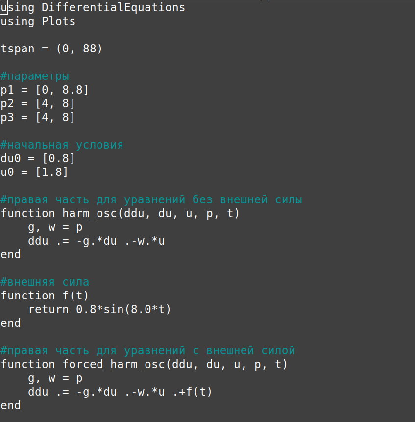

Рисунок 1: Функции в julia

## Реализация в Julia и Scilab

Я использую функцию SecondOrderODEProblem для определения проблемы и численный метод DPKN6() для ее решения(рис.2)

## Реализация в Julia и Scilab

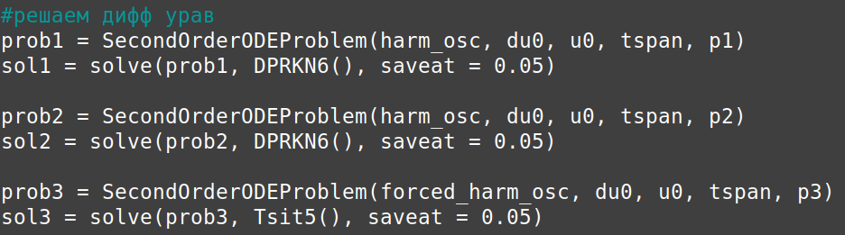

Рисунок 2: Решение Функции

## Реализация в Julia и Scilab

После этого я визуализирую(рис.3)

## Реализация в Julia и Scilab

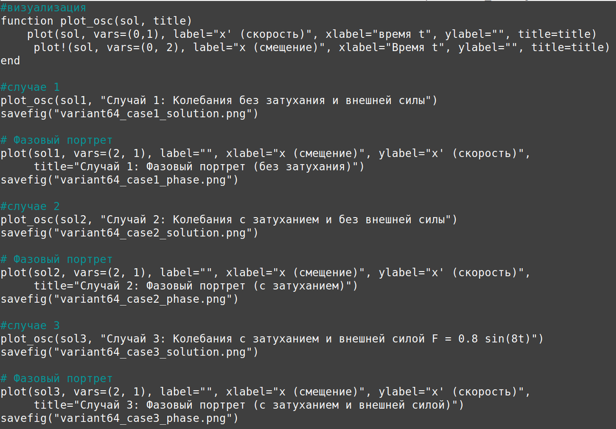

Рисунок 3: Визуализация

## Колебания гармонического осциллятора без затуханий и без действий внешней силы

Графики, которые я получил от julia и scilab, совпадают(рис 4 и 5)

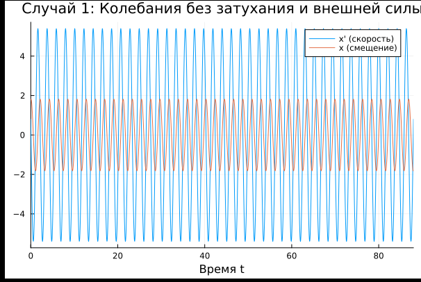

Рисунок 4: Колебания в Julia

## Колебания гармонического осциллятора без затуханий и без действий внешней силы

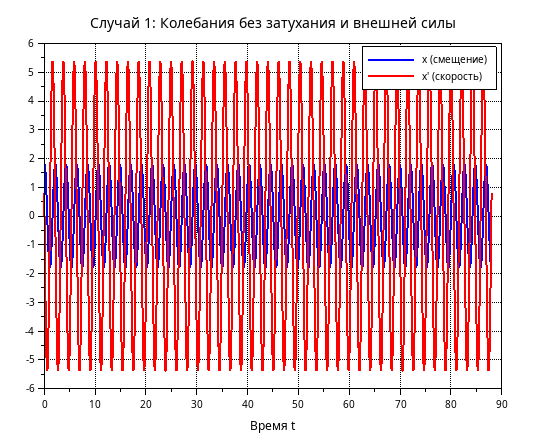

Рисунок 5: Колебания в Scilab

## Колебания гармонического осциллятора без затуханий и без действий внешней силы

Фазовые портреты также одинаковы(рис 6 и 7)

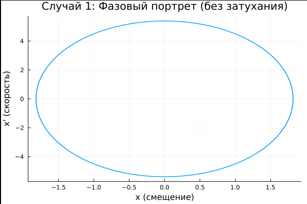

Рисунок 6: Фазовые портреты в Julia

## Колебания гармонического осциллятора без затуханий и без действий внешней силы

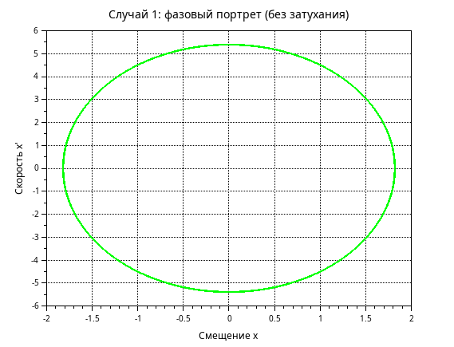

Рисунок 7: Фазовые портреты в Scilab

## Колебания гармонического осциллятора без затуханий и без действий внешней силы

*Мы видим, что генератор периодически совершает колебания, график не исчезает, а решение системы дифференциальных уравнений всегда движется по одной и той же траектории.*

## Колебания гармонического осциллятора с затуханий и без действий внешней силы

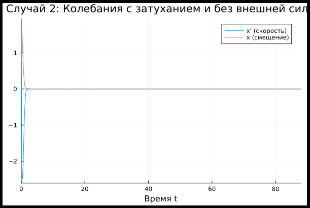

Рисунок 8: Колебания(с затуханием) в Julia

## Колебания гармонического осциллятора с затуханий и без действий внешней силы

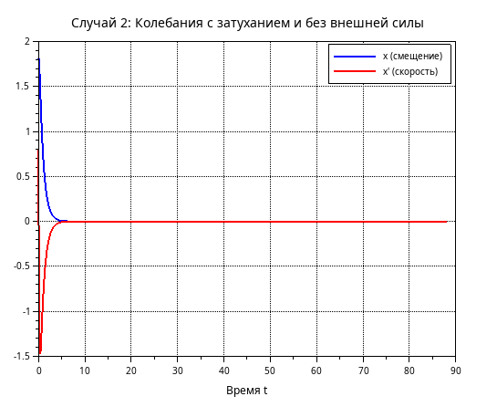

Рисунок 9: Колебания(с затуханием) в Scilab

## Колебания гармонического осциллятора с затуханий и без действий внешней силы

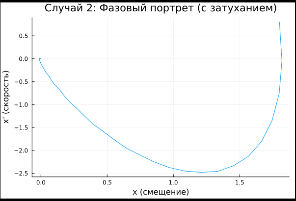

Рисунок 10: Фазовые портреты(с затуханием) в Julia

## Колебания гармонического осциллятора с затуханий и без действий внешней силы

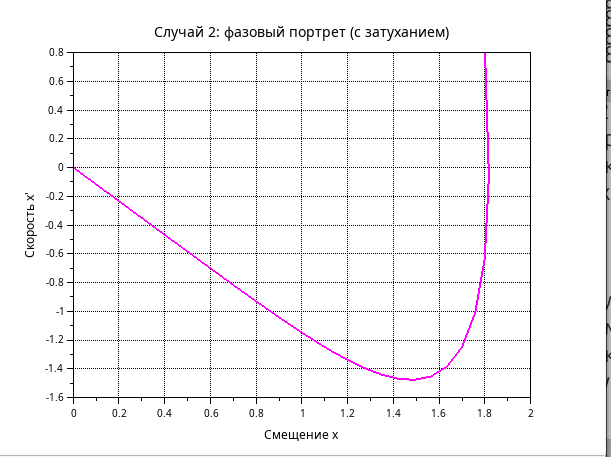

Рисунок 11: Фазовые портреты(с затуханием) в Scilab

## Колебания гармонического осциллятора с затуханий и внешней силы $F(t) = 0.8\sin{(8t)}$

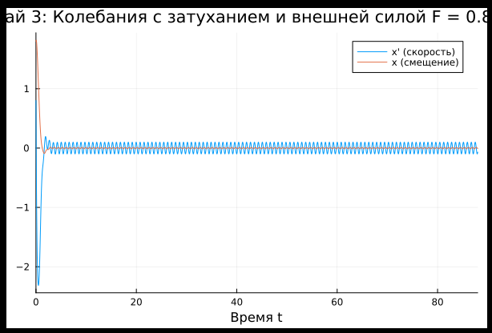

Рисунок 12: Колебания(с затуханием и внешней силы $F(t) = 0.8\sin{(8t)}$) в Julia

## Колебания гармонического осциллятора с затуханий и внешней силы $F(t) = 0.8\sin{(8t)}$

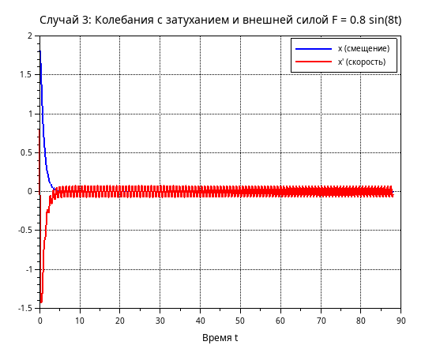

Рисунок 13: Колебания(с затуханием и внешней силы $F(t) = 0.8\sin{(8t)}$) в Scilab

## Колебания гармонического осциллятора с затуханий и внешней силы $F(t) = 0.8\sin{(8t)}$

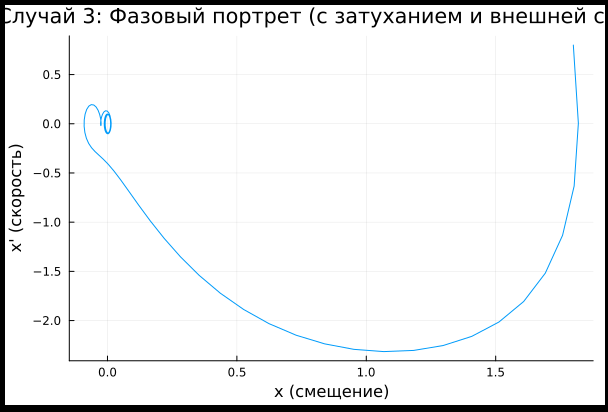

Рисунок 14: Фазовые портреты(с затуханием и внешней силы $F(t) = 0.8\sin{(8t)}$) в Julia

## Колебания гармонического осциллятора с затуханий и внешней силы $F(t) = 0.8\sin{(8t)}$

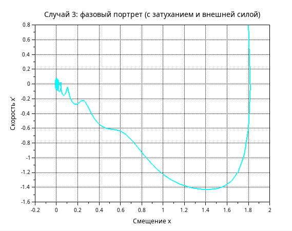

Рисунок 15: Фазовые портреты(с затуханием и внешней силы $F(t) = 0.8\sin{(8t)}$) в Scilab

## Выводы

Выполнив эту лабораторную работу я построила математическую модель гармонического осциллятора и провелила анализ